# PA1_template

### Loading and preprocessing the data

```r
dataset_url <- "https://d396qusza40orc.cloudfront.net/repdata%2Fdata%2Factivity.zip"
download.file(dataset_url, "Activity.zip")
unzip("Activity.zip", exdir = "Activity")

Act <- data.table::fread("Activity/activity.csv")
Act[, date := as.POSIXct(date, format = "%Y-%m-%d")] #Change character tot  to date
str(Act)
```

```
## Classes 'data.table' and 'data.frame':   17568 obs. of  3 variables:
##  $ steps   : int  NA NA NA NA NA NA NA NA NA NA ...
##  $ date    : POSIXct, format: "2012-10-01" "2012-10-01" ...
##  $ interval: int  0 5 10 15 20 25 30 35 40 45 ...
##  - attr(*, ".internal.selfref")=<externalptr>
```

### Calculate the total number of steps taken per day

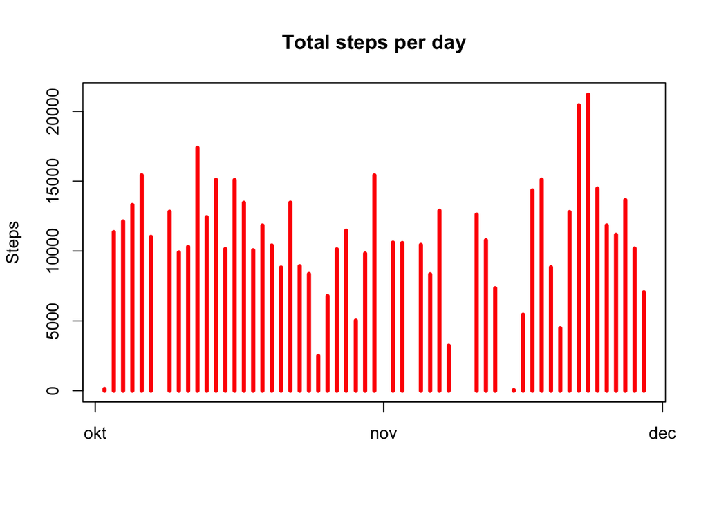

```r
Day_total <- aggregate(steps ~ date, data = Act, sum, na.rm = TRUE)
with(Day_total,plot(date,steps,
              type = "h",
              lwd = 4,
              col="red",
              main="Total steps per day",
              xlab="",
              ylab="Steps"))
```

```r
mean <- as.integer(mean(Day_total$steps))
median <- median(Day_total$steps)
```

The mean is 10766 and the median is 10765 steps per day

### Make a time series plot (i.e. type=“l”) of the 5-minute interval (x-axis) and the average number of steps taken, averaged across all days (y-axis)

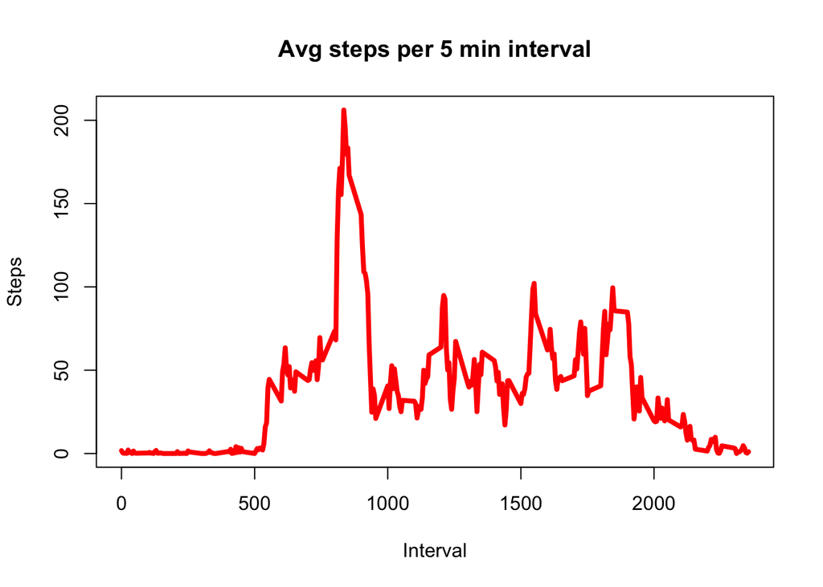

```r
Act_CC <- Act[complete.cases(Act), ]

Interval_mean = aggregate(steps ~ interval, data = Act_CC, FUN = "mean", na.rm = TRUE)


with(Interval_mean,plot(interval,steps,
                        type = "l",
                        lwd = 4,
                        col="red",
                        main="Avg steps per 5 min interval",
                        xlab="Interval",
                        ylab="Steps"))
```

### Which 5-minute interval, on average across all the days in the dataset, contains the maximum number of steps?

```r
max_steps <- Interval_mean$interval[max.col(t(Interval_mean$steps))]
```

The max number of steps is found in the interval: 835

### Calculate and report the total number of missing values in the dataset (i.e. the total number of rows with NAs)

```r
NA_Count <- Act[is.na(steps), .N ] #Number of missing values
Total_Rows <- Act[, .N ] #Number of rows
NA_Percentage <- round((NA_Count / Total_Rows) *100,2)
```

The number of missing values is 2304 (13.11%)

### Create a new dataset that is equal to the original dataset but with the missing data filled in.

I decided to replace the missing values with te avarage number of steps of that interval

```r
Act_NA <- data.frame(Act)

library(zoo)
Act_NA <- transform(Act_NA, steps = na.aggregate(steps, by = interval))
summary(Act_NA)
```

```
##      steps             date                        interval
##  Min.   :  0.00   Min.   :2012-10-01 00:00:00   Min.   :   0.0
##  1st Qu.:  0.00   1st Qu.:2012-10-16 00:00:00   1st Qu.: 588.8
##  Median :  0.00   Median :2012-10-31 00:00:00   Median :1177.5
##  Mean   : 37.38   Mean   :2012-10-30 23:32:27   Mean   :1177.5
##  3rd Qu.: 27.00   3rd Qu.:2012-11-15 00:00:00   3rd Qu.:1766.2
##  Max.   :806.00   Max.   :2012-11-30 00:00:00   Max.   :2355.0
```

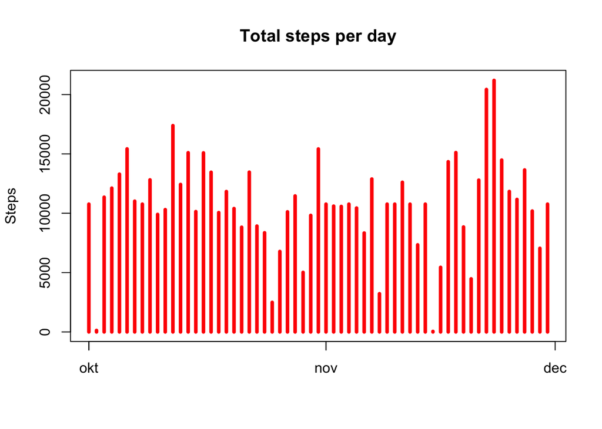

```r
Day_total_NA <- aggregate(steps ~ date, data = Act_NA, sum)

with(Day_total_NA,plot(date,steps,
                    type = "h",
                    lwd = 4,
                    col="red",
                    main="Total steps per day",
                    xlab="",
                    ylab="Steps"))
```

### Calculate and report the mean and median total number of steps taken per day.

```r
Mean_after <- as.integer(mean(Day_total_NA$steps))
Median_after <- as.integer(median(Day_total_NA$steps))
```

The mean after handling the missing values is 10766 and the median is 10766

### Panel plot comparing the average number of steps taken per 5-minute interval across weekdays and weekends

[output not shown]

```
## [1] "en_US"
```

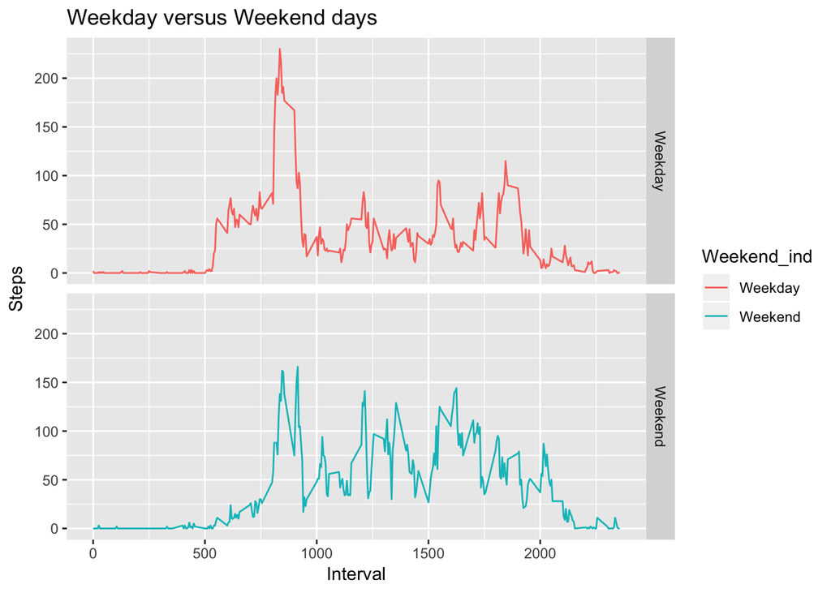

```r
Act_NA$Weekday <- as.factor(weekdays(Act_NA$date))
Act_NA$Weekend_ind = as.factor(ifelse(Act_NA$Weekday == "Saturday" | Act_NA$Weekday == "Sunday" ,"Weekend","Weekday"))

Weekend_interval <- aggregate(steps ~  interval + Weekend_ind, data = Act_NA, FUN = "mean")
Weekend_interval$steps <- as.integer(Weekend_interval$steps)

library(ggplot2)

ggplot(Weekend_interval, aes(interval, steps)) +
  geom_line(stat = "identity", aes(colour = Weekend_ind)) +
  theme_gray() +
  facet_grid(Weekend_ind ~ ., scales="fixed", space="fixed") +
  labs(x="Interval", y=expression("Steps")) +
  ggtitle("Weekday versus Weekend days")
```